# امیرحسین علیزاد 810197546

# پروژه ی 0

**در این تمرین کامپیوتری سعی داریم با استفاده از داده های خوانده شده از یک فایل نقصی های آن را مانند سن افراد، استفاده روزانه از اینترنت و ... ان هارا کامل کنیم و در نهایت بهترین ویژگی از میان این ویژگی هارا انتخاب کنیم تا با استفاده از ان بتوانیم پیش بینی کنیم که ایا افرادی که ستون کلیک کردن بر روی تبلیغ برای انها خالی است روی تبلیغ کلیک میکنند یا خیر**

# پس از هر قطعه کد توضیحات مربوط به آن در سلول بعدی آن نشان داده شده است

# بخش اول

## tail() استفاده از تابع

```python
import pandas as pd
df = pd.read_csv('advertising_dataset.csv')
df.tail()
```

|  | Unnamed: 0 | Daily Time Spent on Site | Age | Area Income | Daily Internet Usage | Ad Topic Line | City | Gender | Country | Timestamp | Clicked on Ad |
| --- | --- | --- | --- | --- | --- | --- | --- | --- | --- | --- | --- |
| 995 | 995 | 72.97 | 30.0 | 71384.57 | 208.58 | Fundamental modular algorithm | Duffystad | Male | Lebanon | 2016-02-11 21:49:00 | 1.0 |
| 996 | 996 | 51.30 | 45.0 | 67782.17 | 134.42 | Grass-roots cohesive monitoring | New Darlene | Male | Bosnia and Herzegovina | 2016-04-22 02:07:01 | 1.0 |
| 997 | 997 | 51.63 | 51.0 | 42415.72 | 120.37 | Expanded intangible solution | South Jessica | Male | Mongolia | 2016-02-01 17:24:57 | 1.0 |
| 998 | 998 | 55.55 | 19.0 | 41920.79 | 187.95 | Proactive bandwidth-monitored policy | West Steven | Female | Guatemala | 2016-03-24 02:35:54 | 0.0 |
| 999 | 999 | NaN | 26.0 | 29875.80 | 178.35 | Virtual 5thgeneration emulation | Ronniemouth | Female | Brazil | 2016-06-03 21:43:21 | 1.0 |

**read_csv() با استفاده از تابع**  
**داده های موجود در فایل را در یک دیتافرم ذخیره میکنیم**  
**همانطور که مشاهده میشود این تابع 5 ردیف اخر داده ها را نشان میدهد**

```python
df.tail(2)
```

|  | Unnamed: 0 | Daily Time Spent on Site | Age | Area Income | Daily Internet Usage | Ad Topic Line | City | Gender | Country | Timestamp | Clicked on Ad |
| --- | --- | --- | --- | --- | --- | --- | --- | --- | --- | --- | --- |
| 998 | 998 | 55.55 | 19.0 | 41920.79 | 187.95 | Proactive bandwidth-monitored policy | West Steven | Female | Guatemala | 2016-03-24 02:35:54 | 0.0 |
| 999 | 999 | NaN | 26.0 | 29875.80 | 178.35 | Virtual 5thgeneration emulation | Ronniemouth | Female | Brazil | 2016-06-03 21:43:21 | 1.0 |

**این تابع میتواند ورودی داشته باشد که به تعداد ورودی ردیف های اخر داده را نشان میدهد و به طور پیش فرض برابر 5 است**

## head() استفاده از تابع

```python
df.head()
```

|  | Unnamed: 0 | Daily Time Spent on Site | Age | Area Income | Daily Internet Usage | Ad Topic Line | City | Gender | Country | Timestamp | Clicked on Ad |
| --- | --- | --- | --- | --- | --- | --- | --- | --- | --- | --- | --- |
| 0 | 0 | 68.95 | 35.0 | 61833.90 | 256.09 | Cloned 5thgeneration orchestration | Wrightburgh | Female | Tunisia | 2016-03-27 00:53:11 | 0.0 |
| 1 | 1 | 80.23 | 31.0 | 68441.85 | NaN | Monitored national standardization | West Jodi | Male | Nauru | 2016-04-04 01:39:02 | 0.0 |
| 2 | 2 | 69.47 | 26.0 | 59785.94 | 236.50 | Organic bottom-line service-desk | Davidton | Female | San Marino | 2016-03-13 20:35:42 | 0.0 |
| 3 | 3 | 74.15 | 29.0 | 54806.18 | 245.89 | Triple-buffered reciprocal time-frame | West Terrifurt | Male | Italy | 2016-01-10 02:31:19 | 0.0 |
| 4 | 4 | 68.37 | 35.0 | 73889.99 | 225.58 | Robust logistical utilization | South Manuel | Female | Iceland | 2016-06-03 03:36:18 | 0.0 |

**مشاهده میشود این تابع 5 ردیف اول داده ها را نشان میدهد**

```python
df.head(2)
```

|  | Unnamed: 0 | Daily Time Spent on Site | Age | Area Income | Daily Internet Usage | Ad Topic Line | City | Gender | Country | Timestamp | Clicked on Ad |
| --- | --- | --- | --- | --- | --- | --- | --- | --- | --- | --- | --- |
| 0 | 0 | 68.95 | 35.0 | 61833.90 | 256.09 | Cloned 5thgeneration orchestration | Wrightburgh | Female | Tunisia | 2016-03-27 00:53:11 | 0.0 |
| 1 | 1 | 80.23 | 31.0 | 68441.85 | NaN | Monitored national standardization | West Jodi | Male | Nauru | 2016-04-04 01:39:02 | 0.0 |

**این تابع نیز میتواند ورودی داشته باشد که به تعداد ورودی ردیف های اول داده را نشان میدهد و به طور پیش فرض برابر 5 است**

## describe() استفاده از تابع

```python
df.describe()
```

|  | Unnamed: 0 | Daily Time Spent on Site | Age | Area Income | Daily Internet Usage | Clicked on Ad |
| --- | --- | --- | --- | --- | --- | --- |
| count | 1000.000000 | 907.000000 | 979.000000 | 1000.000000 | 913.000000 | 832.000000 |
| mean | 499.500000 | 64.794818 | 36.009193 | 55000.000080 | 179.751271 | 0.496394 |
| std | 288.819436 | 15.954841 | 8.783636 | 13414.634022 | 43.957934 | 0.500288 |
| min | 0.000000 | 32.600000 | 19.000000 | 13996.500000 | 104.780000 | 0.000000 |
| 25% | 249.750000 | 50.615000 | 29.000000 | 47031.802500 | 138.550000 | 0.000000 |
| 50% | 499.500000 | 67.940000 | 35.000000 | 57012.300000 | 183.480000 | 0.000000 |
| 75% | 749.250000 | 78.555000 | 42.000000 | 65470.635000 | 217.850000 | 1.000000 |
| max | 999.000000 | 91.430000 | 61.000000 | 79484.800000 | 269.960000 | 1.000000 |

**این تابع برای هر ستون مقادیری مانند تعداد، میانگین، انحراف معیار، کوچکترین مقدار، بزرگترین مقدار و صدک های پایینی، میانی و بالایی را نشان میدهد**  
**به طور پیش فرض صدک پایینی برابر 25 و صدک بالایی برابر 75 است**  
**صدک میانی همان میانه است**

# بخش دوم

## info() استفاده از تابع

```python
df.info()
```

```
<class 'pandas.core.frame.DataFrame'>
RangeIndex: 1000 entries, 0 to 999
Data columns (total 11 columns):
 #   Column                    Non-Null Count  Dtype
---  ------                    --------------  -----
 0   Unnamed: 0                1000 non-null   int64
 1   Daily Time Spent on Site  907 non-null    float64
 2   Age                       979 non-null    float64
 3   Area Income               1000 non-null   float64
 4   Daily Internet Usage      913 non-null    float64
 5   Ad Topic Line             1000 non-null   object
 6   City                      1000 non-null   object
 7   Gender                    1000 non-null   object
 8   Country                   1000 non-null   object
 9   Timestamp                 1000 non-null   object
 10  Clicked on Ad             832 non-null    float64
dtypes: float64(5), int64(1), object(5)
memory usage: 66.5+ KB
```

**مشاهده میشود که برای هر ستون تعداد مقادیری که ستون انها خالی نیست و نوع داده ای آنها و میزان حافظه ی مصرفی را نشان میدهد**

# برچسب گذاری

**categorial در بسیاری از داده هایی که در اختیار ما قراره داده میشود ممکن است در دیتاست ما داده هایی با نوع**  
**وجود دارد که با کلمه یا حرف نشان داده میشوند و سعی ما بر این است که این نوع داده ها را به داده عددی تبدیل کنیم**

```python
new_dic = {"Gender" : {"Male" : 1, "Female" : 0}}
df.replace(new_dic, inplace = True)
df
```

|  | Unnamed: 0 | Daily Time Spent on Site | Age | Area Income | Daily Internet Usage | Ad Topic Line | City | Gender | Country | Timestamp | Clicked on Ad |
| --- | --- | --- | --- | --- | --- | --- | --- | --- | --- | --- | --- |
| 0 | 0 | 68.95 | 35.0 | 61833.90 | 256.09 | Cloned 5thgeneration orchestration | Wrightburgh | 0 | Tunisia | 2016-03-27 00:53:11 | 0.0 |
| 1 | 1 | 80.23 | 31.0 | 68441.85 | NaN | Monitored national standardization | West Jodi | 1 | Nauru | 2016-04-04 01:39:02 | 0.0 |
| 2 | 2 | 69.47 | 26.0 | 59785.94 | 236.50 | Organic bottom-line service-desk | Davidton | 0 | San Marino | 2016-03-13 20:35:42 | 0.0 |
| 3 | 3 | 74.15 | 29.0 | 54806.18 | 245.89 | Triple-buffered reciprocal time-frame | West Terrifurt | 1 | Italy | 2016-01-10 02:31:19 | 0.0 |
| 4 | 4 | 68.37 | 35.0 | 73889.99 | 225.58 | Robust logistical utilization | South Manuel | 0 | Iceland | 2016-06-03 03:36:18 | 0.0 |
| ... | ... | ... | ... | ... | ... | ... | ... | ... | ... | ... | ... |
| 995 | 995 | 72.97 | 30.0 | 71384.57 | 208.58 | Fundamental modular algorithm | Duffystad | 1 | Lebanon | 2016-02-11 21:49:00 | 1.0 |
| 996 | 996 | 51.30 | 45.0 | 67782.17 | 134.42 | Grass-roots cohesive monitoring | New Darlene | 1 | Bosnia and Herzegovina | 2016-04-22 02:07:01 | 1.0 |
| 997 | 997 | 51.63 | 51.0 | 42415.72 | 120.37 | Expanded intangible solution | South Jessica | 1 | Mongolia | 2016-02-01 17:24:57 | 1.0 |
| 998 | 998 | 55.55 | 19.0 | 41920.79 | 187.95 | Proactive bandwidth-monitored policy | West Steven | 0 | Guatemala | 2016-03-24 02:35:54 | 0.0 |
| 999 | 999 | NaN | 26.0 | 29875.80 | 178.35 | Virtual 5thgeneration emulation | Ronniemouth | 0 | Brazil | 2016-06-03 21:43:21 | 1.0 |

1000 rows × 11 columns

**مقادیر مرد = 1 و زن = 0 تعریف شده است gender برای این کار ابتدا یک دیکشنری تعریف میکنیم که برای ستون**  
**replace()با استفاده از تابع**  
**مقادیر ستون جنسیت را در صورتی که مرد باشد با مقدار 1 و اگر زن باشد با مقدار 0 جایگزین میکنیم**  
**inplace = True**  
**نشان میدهد که مقادیر درجا تغییر داده شوند به این معنی که در خود دیتا فرم این اتفاق بیفتد**

# بخش سوم

## تعداد سطر های خالی برای هر ستون

```python
df.isna().sum()
```

```
Unnamed: 0                    0
Daily Time Spent on Site     93
Age                          21
Area Income                   0
Daily Internet Usage         87
Ad Topic Line                 0
City                          0
Gender                        0
Country                       0
Timestamp                     0
Clicked on Ad               168
dtype: int64
```

**isna()**  
**قرار میدهد False و در غیر اینصورت جای آن True مشخص میکند که در صورتی که سطری خالی باشد جای آن**  
**isna().sum()**  
**برای هر ستون را میشمارد و در خروجی نشان میدهد True پس از انجام عمل بالا تعداد مقادیر**

**میتوان با داده های خالی طوری رفتار کرد که وجود ندارند و آنهارا در نظر نگیریم اما در این تمرین میخواهیم سطر های خالی را با میانگین آن ستون پر کنیم**

```python
import numpy as np
desc = df.describe()
df['Daily Time Spent on Site'] = df['Daily Time Spent on Site'].fillna(desc['Daily Time Spent on Site']['mean'])
df['Age'] = df['Age'].fillna(desc['Age']['mean'])
df['Daily Internet Usage'] = df['Daily Internet Usage'].fillna(desc['Daily Internet Usage']['mean'])
df
```

|  | Unnamed: 0 | Daily Time Spent on Site | Age | Area Income | Daily Internet Usage | Ad Topic Line | City | Gender | Country | Timestamp | Clicked on Ad |
| --- | --- | --- | --- | --- | --- | --- | --- | --- | --- | --- | --- |
| 0 | 0 | 68.950000 | 35.0 | 61833.90 | 256.090000 | Cloned 5thgeneration orchestration | Wrightburgh | 0 | Tunisia | 2016-03-27 00:53:11 | 0.0 |
| 1 | 1 | 80.230000 | 31.0 | 68441.85 | 179.751271 | Monitored national standardization | West Jodi | 1 | Nauru | 2016-04-04 01:39:02 | 0.0 |
| 2 | 2 | 69.470000 | 26.0 | 59785.94 | 236.500000 | Organic bottom-line service-desk | Davidton | 0 | San Marino | 2016-03-13 20:35:42 | 0.0 |
| 3 | 3 | 74.150000 | 29.0 | 54806.18 | 245.890000 | Triple-buffered reciprocal time-frame | West Terrifurt | 1 | Italy | 2016-01-10 02:31:19 | 0.0 |
| 4 | 4 | 68.370000 | 35.0 | 73889.99 | 225.580000 | Robust logistical utilization | South Manuel | 0 | Iceland | 2016-06-03 03:36:18 | 0.0 |
| ... | ... | ... | ... | ... | ... | ... | ... | ... | ... | ... | ... |
| 995 | 995 | 72.970000 | 30.0 | 71384.57 | 208.580000 | Fundamental modular algorithm | Duffystad | 1 | Lebanon | 2016-02-11 21:49:00 | 1.0 |
| 996 | 996 | 51.300000 | 45.0 | 67782.17 | 134.420000 | Grass-roots cohesive monitoring | New Darlene | 1 | Bosnia and Herzegovina | 2016-04-22 02:07:01 | 1.0 |
| 997 | 997 | 51.630000 | 51.0 | 42415.72 | 120.370000 | Expanded intangible solution | South Jessica | 1 | Mongolia | 2016-02-01 17:24:57 | 1.0 |
| 998 | 998 | 55.550000 | 19.0 | 41920.79 | 187.950000 | Proactive bandwidth-monitored policy | West Steven | 0 | Guatemala | 2016-03-24 02:35:54 | 0.0 |
| 999 | 999 | 64.794818 | 26.0 | 29875.80 | 178.350000 | Virtual 5thgeneration emulation | Ronniemouth | 0 | Brazil | 2016-06-03 21:43:21 | 1.0 |

1000 rows × 11 columns

**describe() با استفاده از تابع**  
**fillna() میانگین هر ستون را بدست میاوریم و در نهایت با استفاده از تابع**  
**ستون های خالی هر سطر را با میانگین آن ستون تعویض میکنیم**

```python
df.isna().sum()
```

```
Unnamed: 0                    0
Daily Time Spent on Site      0
Age                           0
Area Income                   0
Daily Internet Usage          0
Ad Topic Line                 0
City                          0
Gender                        0
Country                       0
Timestamp                     0
Clicked on Ad               168
dtype: int64
```

**همانطور ک مشاهده میشود تعداد سطر های خالی در هر ستون بجز ستون آخر برابر 0 شده است**

# بخش چهارم

**value_counts() با استفاده از تابع**  
**میتوان نشان داد که در هر ستون از هر مقدار چه تعدادی وجود دارد**

```python
df['Gender'].value_counts()
```

```
0    519
1    481
Name: Gender, dtype: int64
```

```python
df['Clicked on Ad'].value_counts()
```

```
0.0    419
1.0    413
Name: Clicked on Ad, dtype: int64
```

# بخش پنجم

**در داده های ما باید سن افراد بالای 21 و همچنین جنسیت آنها برابر 1 باشد که به روش زیر میتوان آنهارا ب دست اورد**

```python
older_and_male = df[(df['Gender'] == 1) & (df['Age'] > 21)]
older_and_male
```

|  | Unnamed: 0 | Daily Time Spent on Site | Age | Area Income | Daily Internet Usage | Ad Topic Line | City | Gender | Country | Timestamp | Clicked on Ad |
| --- | --- | --- | --- | --- | --- | --- | --- | --- | --- | --- | --- |
| 1 | 1 | 80.23 | 31.0 | 68441.85 | 179.751271 | Monitored national standardization | West Jodi | 1 | Nauru | 2016-04-04 01:39:02 | 0.0 |
| 3 | 3 | 74.15 | 29.0 | 54806.18 | 245.890000 | Triple-buffered reciprocal time-frame | West Terrifurt | 1 | Italy | 2016-01-10 02:31:19 | 0.0 |
| 5 | 5 | 59.99 | 23.0 | 59761.56 | 226.740000 | Sharable client-driven software | Jamieberg | 1 | Norway | 2016-05-19 14:30:17 | 0.0 |
| 7 | 7 | 66.00 | 48.0 | 24593.33 | 131.760000 | Reactive local challenge | Port Jefferybury | 1 | Australia | 2016-03-07 01:40:15 | 1.0 |
| 8 | 8 | 74.53 | 30.0 | 68862.00 | 221.510000 | Configurable coherent function | West Colin | 1 | Grenada | 2016-04-18 09:33:42 | 0.0 |
| ... | ... | ... | ... | ... | ... | ... | ... | ... | ... | ... | ... |
| 991 | 991 | 38.96 | 38.0 | 36497.22 | 140.670000 | Versatile mission-critical application | Mauricefurt | 1 | Comoros | 2016-07-21 16:02:40 | 1.0 |
| 993 | 993 | 64.20 | 27.0 | 66200.96 | 227.630000 | Phased zero tolerance extranet | Edwardsmouth | 1 | Isle of Man | 2016-02-11 23:45:01 | 0.0 |
| 995 | 995 | 72.97 | 30.0 | 71384.57 | 208.580000 | Fundamental modular algorithm | Duffystad | 1 | Lebanon | 2016-02-11 21:49:00 | 1.0 |
| 996 | 996 | 51.30 | 45.0 | 67782.17 | 134.420000 | Grass-roots cohesive monitoring | New Darlene | 1 | Bosnia and Herzegovina | 2016-04-22 02:07:01 | 1.0 |
| 997 | 997 | 51.63 | 51.0 | 42415.72 | 120.370000 | Expanded intangible solution | South Jessica | 1 | Mongolia | 2016-02-01 17:24:57 | 1.0 |

468 rows × 11 columns

```python
older_and_male.count()
```

```
Unnamed: 0                  468
Daily Time Spent on Site    468
Age                         468
Area Income                 468
Daily Internet Usage        468
Ad Topic Line               468
City                        468
Gender                      468
Country                     468
Timestamp                   468
Clicked on Ad               397
dtype: int64
```

**count() با استفاده از تابع**  
**تعداد داده های موجود در دیتافرم و در هر ستون را میتوان بدست آورد**

# بخش ششم

**Vectorization** **روشی سریع در کتابخانه نامپای است که میتوان به جای اینکه هر عنصر از دیتا را پیشمایش کنیم از این روش استفاده کنیم**

```python
import time
t1 = time.time()
print(df.groupby('Clicked on Ad').mean()['Age'])
t2 = time.time()
t2 - t1
```

```
Clicked on Ad
0.0    31.723326
1.0    40.295600
Name: Age, dtype: float64
```

```
0.003993511199951172
```

**groupby() با استفاده از تابع**  
**mean() که ورودی آن نام ستون مورد نظر است و به استفاده از متُد**  
**میتوان میانگین ستون دلخواه که در این مورد سن است را بدست میاوریم**

# بخش هفتم

```python
import math
x = 0
t = 0
y = 0
z = 0
t3 = time.time()
length = len(df['Clicked on Ad'])
for i in range(1000):
    if df['Clicked on Ad'][i] == 1:
        x += df['Age'][i]
        t += 1
    elif df['Clicked on Ad'][i] == 0:
        y += df['Age'][i]
        z += 1
print("0.0", y / z)
print("1.0", x / t)
t4 = time.time()
t4 - t3
```

```
0.0 31.723325881701896
1.0 40.295599848637366
```

```
0.017950057983398438
```

**این بار عمل میانگین گیری را با حلقه انجام میدهیم و همانطور که دیده میشود این عمل تقریبا 4 الی 5 برابر کند تر از روش بخش ششم انجام شده است**  
**بدون حلقه : 0.0039**  
**با حلقه : 0.0179**  
**که البته در دیتا فرم با تعداد بیشتر از 1000 داده این تغییر زمانی محسوس تر نیز خواهد شد**

# بخش هشتم

**در این بخش قسمت هایی که مقدار عددی دارند روی هیستوگرام نمایش داده میشوند**

# مقدار زمان گذرانده در سایت در طول روز

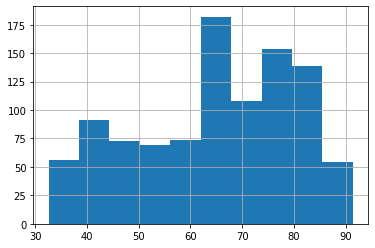

```python
df['Daily Time Spent on Site'].hist()
```

# سن

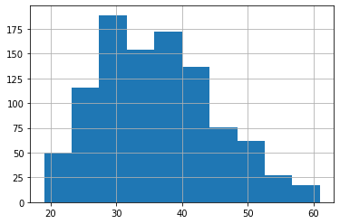

```python
df['Age'].hist()
```

# درآمد منطقه

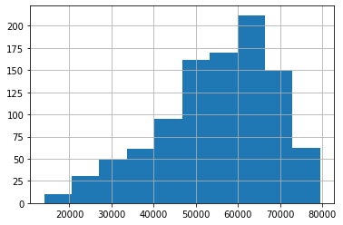

```python
df['Area Income'].hist()
```

# میزان مصرف روزانه اینترنت

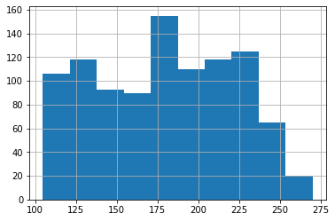

```python
df['Daily Internet Usage'].hist()
```

# کلیک کردن روی تبلیغ

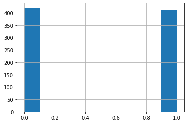

```python
df['Clicked on Ad'].hist()
```

```python
df = df.drop(columns=['Ad Topic Line', 'City','Country' , 'Timestamp' , 'Gender'])
```

# بخش نهم

## نرمال سازی داده ها

**در دنیای واقعی بعضی از داده ها ممکن است با داده های دیگر همان ستون تفاوت های بسیار زیادی داشته باشند و با نرمال سازی داده ها میتوان این مقیاس را کوچکتر کرده تا کار کردن با این داده ها برای ما راحت تر شود**  
**برای نرمال سازی داده ها روش های زیادی وجود دارد که در این تمرین ما داده ی مورد نظر را از میانگین کم کرده و در نهایت برانحراف معیار تقسیم میکنیم**

```python
df['Daily Time Spent on Site'] = (df['Daily Time Spent on Site'] - df['Daily Time Spent on Site'].mean()) / df['Daily Time Spent on Site'].std()
df['Age'] = (df['Age'] - df['Age'].mean()) / df['Age'].std()
df['Area Income'] = (df['Area Income'] - df['Area Income'].mean()) / df['Area Income'].std()
df['Daily Internet Usage'] = (df['Daily Internet Usage'] - df['Daily Internet Usage'].mean()) / df['Daily Internet Usage'].std()
df
```

|  | Unnamed: 0 | Daily Time Spent on Site | Age | Area Income | Daily Internet Usage | Clicked on Ad |
| --- | --- | --- | --- | --- | --- | --- |
| 0 | 0 | 0.273474 | -0.116122 | 0.509436 | 1.817578 | 0.0 |
| 1 | 1 | 1.015870 | -0.576377 | 1.002029 | 0.000000 | 0.0 |
| 2 | 2 | 0.307698 | -1.151696 | 0.356770 | 1.351152 | 0.0 |
| 3 | 3 | 0.615713 | -0.806505 | -0.014448 | 1.574722 | 0.0 |
| 4 | 4 | 0.235301 | -0.116122 | 1.408163 | 1.091154 | 0.0 |
| ... | ... | ... | ... | ... | ... | ... |
| 995 | 995 | 0.538051 | -0.691441 | 1.221395 | 0.686394 | 1.0 |
| 996 | 996 | -0.888164 | 1.034517 | 0.952853 | -1.079309 | 1.0 |
| 997 | 997 | -0.866445 | 1.724900 | -0.938101 | -1.413831 | 1.0 |
| 998 | 998 | -0.608450 | -1.957144 | -0.974996 | 0.195207 | 0.0 |
| 999 | 999 | 0.000000 | -1.151696 | -1.872895 | -0.033363 | 1.0 |

1000 rows × 6 columns

**برای نرمال سازی داده ها در هر ستون مقدار داده های هر ستون را از میانگین آن ستون کم میکنیم و در نهایت بر انحراف معیار ان ستون تقسیم میکنیم**  
**replace() میتوانستیم از تابع**  
**می بود inplace = True نیز استفاده کنیم ک در این صورت نیز مانند قسمت های قبلی باید**

# بخش دهم

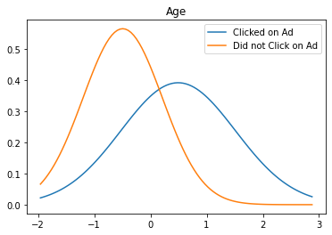

```python
import matplotlib.pyplot as plt
import scipy.stats as ss
mean = df.groupby(df['Clicked on Ad']).mean()
std = df.groupby(df['Clicked on Ad']).std()
x = np.linspace( df['Age'].min(), df['Age'].max(), 100)
plt.title('Age')
plt.plot(x, ss.norm.pdf(x, mean['Age'][1], std['Age'][1]), label = "Clicked on Ad")
plt.plot(x, ss.norm.pdf(x, mean['Age'][0], std['Age'][0]), label = "Did not Click on Ad")
plt.legend()
plt.show()
```

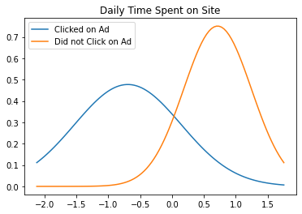

```python
x = np.linspace(df['Daily Time Spent on Site'].min(), df['Daily Time Spent on Site'].max(), 100)
plt.title('Daily Time Spent on Site')
plt.plot(x, ss.norm.pdf(x, mean['Daily Time Spent on Site'][1], std['Daily Time Spent on Site'][1]), label = "Clicked on Ad")
plt.plot(x, ss.norm.pdf(x, mean['Daily Time Spent on Site'][0], std['Daily Time Spent on Site'][0]), label = "Did not Click on Ad")
plt.legend()
plt.show()
```

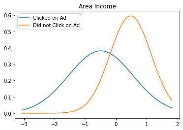

```python
x = np.linspace(df['Area Income'].min(), df['Area Income'].max(), 100)
plt.title('Area Income')
plt.plot(x, ss.norm.pdf(x, mean['Area Income'][1], std['Area Income'][1]), label = "Clicked on Ad")
plt.plot(x, ss.norm.pdf(x, mean['Area Income'][0], std['Area Income'][0]), label = "Did not Click on Ad")
plt.legend()
plt.show()
```

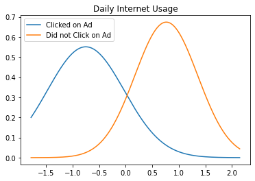

```python
x = np.linspace(df['Daily Internet Usage'].min(), df['Daily Internet Usage'].max(), 1000)
plt.title('Daily Internet Usage')
plt.plot(x, ss.norm.pdf(x, mean['Daily Internet Usage'][1], std['Daily Internet Usage'][1]), label = "Clicked on Ad")
plt.plot(x, ss.norm.pdf(x, mean['Daily Internet Usage'][0], std['Daily Internet Usage'][0]), label = "Did not Click on Ad")
plt.legend()
plt.show()
```

**برای هر ویژگی محدوده را از کمترین مقدار آن ویژگی تا بیشترین مقدار آن ویژگی در نظر گرفته ایم**  
**نمودار های نارنجی مربوط به کلاسی است که روی تبلیغ کلیک نکرده اند و نمودار های آبی برای کلاسی است که روی تبلیغ کلیک کرده اند**  
**با توجه به نمودار های بالا بهترین ویژگی برای پیش بینی مقدار اینترنت مصرفی در روز است**  
**دلیل این انتخاب این است که مقادیر ماکسیمم دو نمودار از هم نسبت به بقیه نمودار ها بیشتر فاصله دارد و همچنین اگر بازه ای به صورت زیر در نظر بگیریم**  
[mean - std : mean + std]  
**این بازه بهترین حالتی که خواهد داشت برای ویژگی مصرف روزانه ی اینترنت خواهد بود**  
**به طور کلی مطلوب ترین انتخاب برای ما ویژگی ای است که دو نمودار آن با هم کمترین اشتراک را داشته باشند**  
**منظور از بهترین حالت این است که میان بازه ها برای دو کلاس اشتراکی وجود ندارد و میانگین این ویژگی برای هر دو کلاس از هم فاصله ی بیشتری نسبت به باقی ویژگی ها دارند**

# بخش یازدهم

```python
pd.options.mode.chained_assignment = None
df_new = df[df['Clicked on Ad'].isnull()]
df_new.loc[(df_new['Daily Internet Usage'] >= (mean['Daily Internet Usage'][1] - std['Daily Internet Usage'][1])) & (df_new['Daily Internet Usage'] <= (mean['Daily Internet Usage'][1] + std['Daily Internet Usage'][1])), 'Clicked on Ad'] = 1
df_new.loc[(df_new['Daily Internet Usage'] >= (mean['Daily Internet Usage'][0] - std['Daily Internet Usage'][0])) & (df_new['Daily Internet Usage'] <= (mean['Daily Internet Usage'][0] + std['Daily Internet Usage'][0])), 'Clicked on Ad'] = 0
df_new['Clicked on Ad'] = df_new['Clicked on Ad'].fillna(1)
df_new.to_csv('out.csv')
```

**با توجه به ویژگی انتخاب شده بازه ی زیر را در نظر میگیریم**  
**[mean - std : mean + std]**  
**isnull() برای پیشبینی ابتدا افرادی که ستون کلیک بر روی تبلیغ برای انها خالی است را با تابع**  
**مشخص کرده سپس برای هر فرد اگر میزان مصرف اینترنت در روز او در بازه ی کلاس 1 بود پیشبینی میکنیم که روی تبلیغ کلیک خواهد کرد و اگر میزان مصرف روزانه اینترنت او در بازه ی کلاس 0 بود پیشبینی میکنیم که روی تبلیغ کلیک نخواهد کرد**  
**برای افرادی که میزان اینترنت مصرفی روزانه ان ها در هیچ کدام از بازه ها قرار نداشت فرض میکنیم که در کلاس 1 قرار خواهند گرفت**

**در دنیای واقعی با داده هایی کار میکنیم که ممکن است بخش هایی از اطلاعات آن در دسترس نبوده باشد و خانه مربوط به آنها خالی باشد**  
**این نوع داده ها باید به روشی رسیدگی شوندچون ممکن است در پیش بینی های ما باعث به وجود آمدن خطا شوند و کار مارا سخت تر کنند**  
**در این تمرین در هر بخش داده ها را بررسی کردیم و بهترین روش برای جایگزین کردن خانه های خالی و رسیدگی به انواع دیگری از داده ها که در اختیار ما قرار گرفته شده بودند را انتخاب کردیم**